# Predict the manner in which activities are performed

J P

27 Sep 2015

### Summary

Using devices such as Jawbone Up, Nike FuelBand, and Fitbit it is now possible to collect a large amount of data about personal activity relatively inexpensively. One thing that people regularly do is quantify how much of a particular activity they do, but they rarely quantify how well they do it.

This analysis is going to predict the manner in how exercise are preformed. Data from accelerometers on the belt, forearm, arm, and dumbbell are collected from 6 participants.

### Data

The data used for this analysis originally come from the source http://groupware.les.inf.puc-rio.br/har and have been partitioned into a training and a testing set. The training set has a column, classe, indicating in which way the excersice was performed.

#### Cleaning

The data sets have some bogus values and many of the columns in the csv files have NA values, these have been removed.

#### Further partitiononing

To prevent from tuning the model fit to the original testing set, during data analysis, the original training set have been split into training and test sets. The original training set is quite large there for only a subset is used for the cross validation procedure.

```r
set.seed(32343)
minitrain <- training[sample(1:nrow(training),1000),]
inTrain <- createDataPartition(
    y=minitrain$classe
    , p=0.75
    , list=FALSE
);
subtraining <- minitrain[inTrain,]
subtesting <- minitrain[-inTrain,]
```

#### Removing unnececarry columns

To predict the classe, non related columns have been removed. Also the findCorrelation function has been used to exclude highly correlated columns, a correlation of 0.8 is used as cutoff.

```r
#removing unrelated columns
subtraining <- subtraining[,!(names(subtraining) %in% grep('^user_*|^total_*|^X$|*_timestamp|*_window',colnames(subtraining), value = TRUE))]

#removing highly correlated columns
subtraining <- subtraining[,-findCorrelation(cor(subtraining[1:ncol(subtraining)-1]),cutoff = .80)]
```

#### A correlation plot of the remaining predictors

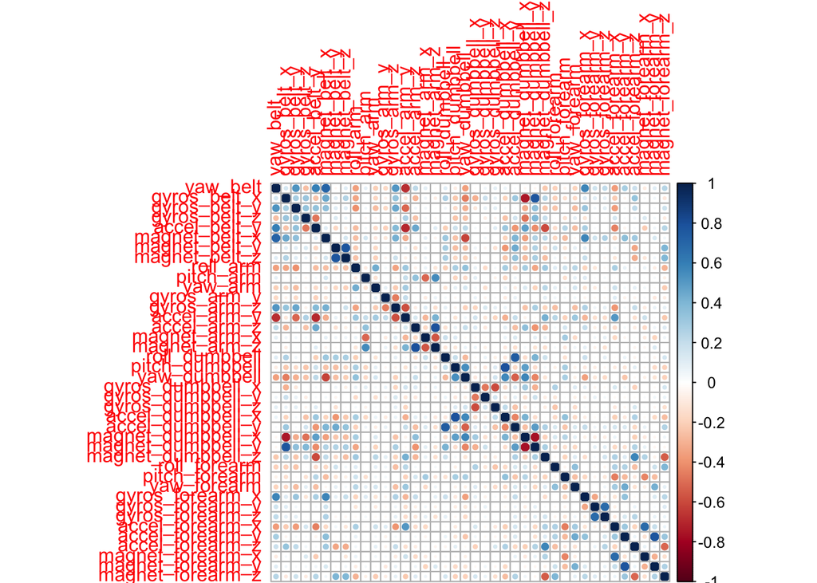

#### Fitting a model

```r
set.seed(32343)
modelFit <- train(classe~.,data = subtraining,method = "rf")
```

#### Creating predictions

```r
predictions <- predict(
    modelFit
    , newdata = subtesting
)
```

#### Confusion Matrix

The output of the confusion matrix indicates a fairly accurate model fit.

```
## Confusion Matrix and Statistics
##
##           Reference
## Prediction  A  B  C  D  E
##          A 61  8  0  3  1
##          B  0 26  1  0  5
##          C  0  8 42  8  1
##          D  5  1  1 33  2
##          E  1  1  0  1 38
##
## Overall Statistics
##
##                Accuracy : 0.8097
##                  95% CI : (0.7551, 0.8567)
##     No Information Rate : 0.2713
##     P-Value [Acc > NIR] : < 2.2e-16
##
##                   Kappa : 0.7596
##  Mcnemar's Test P-Value : NA
##
## Statistics by Class:
##
##                      Class: A Class: B Class: C Class: D Class: E
## Sensitivity            0.9104   0.5909   0.9545   0.7333   0.8085
## Specificity            0.9333   0.9704   0.9163   0.9554   0.9850
## Pos Pred Value         0.8356   0.8125   0.7119   0.7857   0.9268
## Neg Pred Value         0.9655   0.9163   0.9894   0.9415   0.9563
## Prevalence             0.2713   0.1781   0.1781   0.1822   0.1903
## Detection Rate         0.2470   0.1053   0.1700   0.1336   0.1538
## Detection Prevalence   0.2955   0.1296   0.2389   0.1700   0.1660
## Balanced Accuracy      0.9219   0.7807   0.9354   0.8444   0.8968
```